# Introduction :

In this project we will investgate the white wine data, the data contains 4898 observations and 13 variables, the main purpose of the investegation is to figure out what elements are responsible of increasing the quality of the wine,the quality is ranged value where 0 (very bad) and 10 (very excellent) and the rating was conducted by at least 3 wine experts.

```
## 'data.frame':    4898 obs. of  13 variables:
##  $ X                   : int  1 2 3 4 5 6 7 8 9 10 ...
##  $ fixed.acidity       : num  7 6.3 8.1 7.2 7.2 8.1 6.2 7 6.3 8.1 ...
##  $ volatile.acidity    : num  0.27 0.3 0.28 0.23 0.23 0.28 0.32 0.27 0.3 0.22 ...
##  $ citric.acid         : num  0.36 0.34 0.4 0.32 0.32 0.4 0.16 0.36 0.34 0.43 ...
##  $ residual.sugar      : num  20.7 1.6 6.9 8.5 8.5 6.9 7 20.7 1.6 1.5 ...
##  $ chlorides           : num  0.045 0.049 0.05 0.058 0.058 0.05 0.045 0.045 0.049 0.044 ...
##  $ free.sulfur.dioxide : num  45 14 30 47 47 30 30 45 14 28 ...
##  $ total.sulfur.dioxide: num  170 132 97 186 186 97 136 170 132 129 ...
##  $ density             : num  1.001 0.994 0.995 0.996 0.996 ...
##  $ pH                  : num  3 3.3 3.26 3.19 3.19 3.26 3.18 3 3.3 3.22 ...
##  $ sulphates           : num  0.45 0.49 0.44 0.4 0.4 0.44 0.47 0.45 0.49 0.45 ...
##  $ alcohol             : num  8.8 9.5 10.1 9.9 9.9 10.1 9.6 8.8 9.5 11 ...
##  $ quality             : int  6 6 6 6 6 6 6 6 6 6 ...
```

```
##        X        fixed.acidity    volatile.acidity  citric.acid
##  Min.   :   1   Min.   : 3.800   Min.   :0.0800   Min.   :0.0000
##  1st Qu.:1225   1st Qu.: 6.300   1st Qu.:0.2100   1st Qu.:0.2700
##  Median :2450   Median : 6.800   Median :0.2600   Median :0.3200
##  Mean   :2450   Mean   : 6.855   Mean   :0.2782   Mean   :0.3342
##  3rd Qu.:3674   3rd Qu.: 7.300   3rd Qu.:0.3200   3rd Qu.:0.3900
##  Max.   :4898   Max.   :14.200   Max.   :1.1000   Max.   :1.6600
##
##  residual.sugar     chlorides       free.sulfur.dioxide
##  Min.   : 0.600   Min.   :0.00900   Min.   :  2.00
##  1st Qu.: 1.700   1st Qu.:0.03600   1st Qu.: 23.00
##  Median : 5.200   Median :0.04300   Median : 34.00
##  Mean   : 6.391   Mean   :0.04577   Mean   : 35.31
##  3rd Qu.: 9.900   3rd Qu.:0.05000   3rd Qu.: 46.00
##  Max.   :65.800   Max.   :0.34600   Max.   :289.00
##
##  total.sulfur.dioxide    density             pH          sulphates
##  Min.   :  9.0        Min.   :0.9871   Min.   :2.720   Min.   :0.2200
##  1st Qu.:108.0        1st Qu.:0.9917   1st Qu.:3.090   1st Qu.:0.4100
##  Median :134.0        Median :0.9937   Median :3.180   Median :0.4700
##  Mean   :138.4        Mean   :0.9940   Mean   :3.188   Mean   :0.4898
##  3rd Qu.:167.0        3rd Qu.:0.9961   3rd Qu.:3.280   3rd Qu.:0.5500
##  Max.   :440.0        Max.   :1.0390   Max.   :3.820   Max.   :1.0800
##
##     alcohol      quality
##  Min.   : 8.00   3:  20
##  1st Qu.: 9.50   4: 163
##  Median :10.40   5:1457
##  Mean   :10.51   6:2198
##  3rd Qu.:11.40   7: 880
##  Max.   :14.20   8: 175
##                  9:   5
```

looking at the summary above, the first conslusion that comes in mind is that we have a consisted data set with minimal outliers, the means and medains are pretty close in most of the variables, another intersting thing is the difference between the third quartile and the max value in the residual.sugar, and this might be the reason of the difference between the mean and median. the qulaty seems to have only 7 values ( between 3 and 9 )

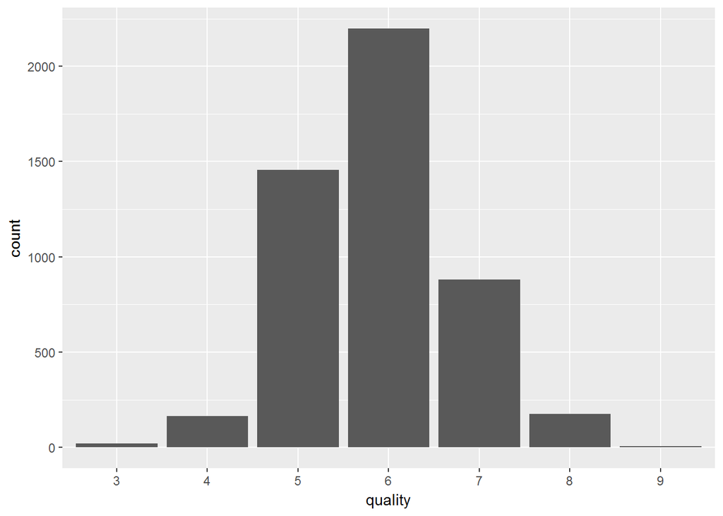

this histogram shows a normal distrubution of the quality, the values start from 3 to 9, the mode is at 6.

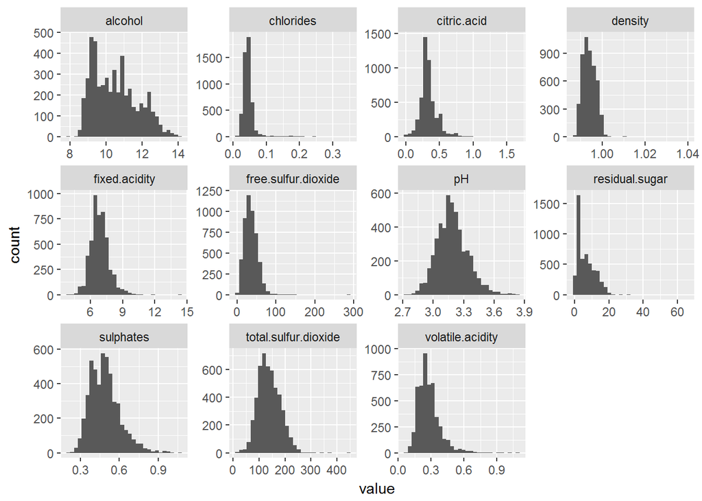

most of the variables shows normal distrubution, except alcohol and residual.sugar, the residual sugars is positively skewed, in the next part i will use log 10 scale in the x-axis for residual.sugar.

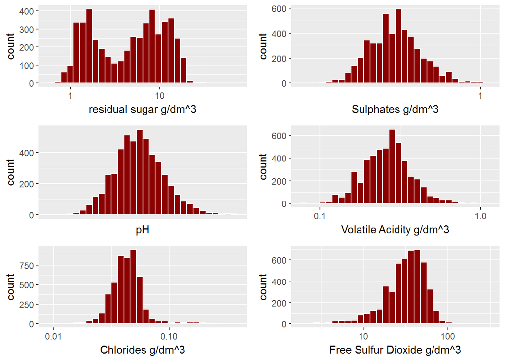

taking the log10 shows a bimodal structure for residual sugar, this way will be easier to explore the data after seeing the unusual distrubution in the previous plot.

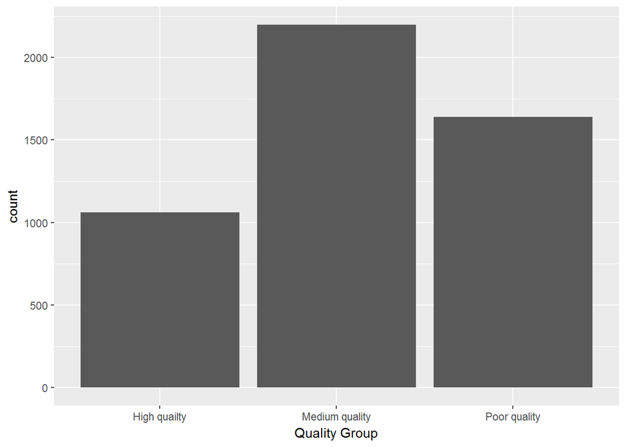

as expected, the medium quality has the most qpperances in the dataset, followed by poor quality then high quality.

# Univariate Analysis

### What is the structure of your dataset?

there are 4898 observations and 13 variables.

### What is/are the main feature(s) of interest in your dataset?

quality of the wine and residual sugars.

### What other features in the dataset do you think will help support your investigation into your feature(s) of interest?

density, total.sulfur.dioxide , alcohol

### Did you create any new variables from existing variables in the dataset?

- poor Quality group : will have the values 3-4-5
- Medium Quality : will have the value 6
- High Quality : will have the values 7-8-9

### Of the features you investigated, were there any unusual distributions? Did you perform any operations on the data to tidy, adjust, or change the form of the data? If so, why did you do this?

# Bivariate Plots Section

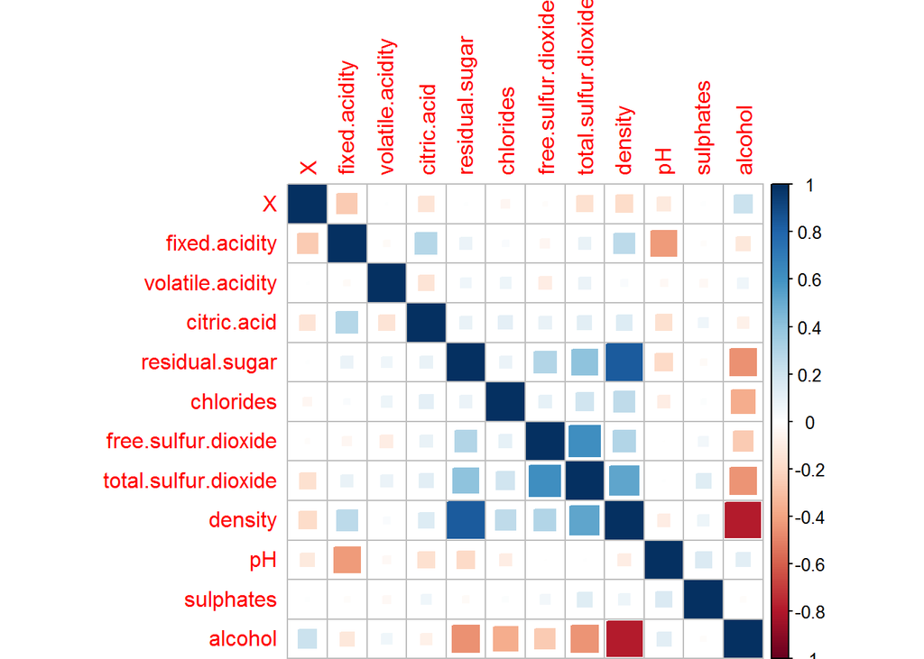

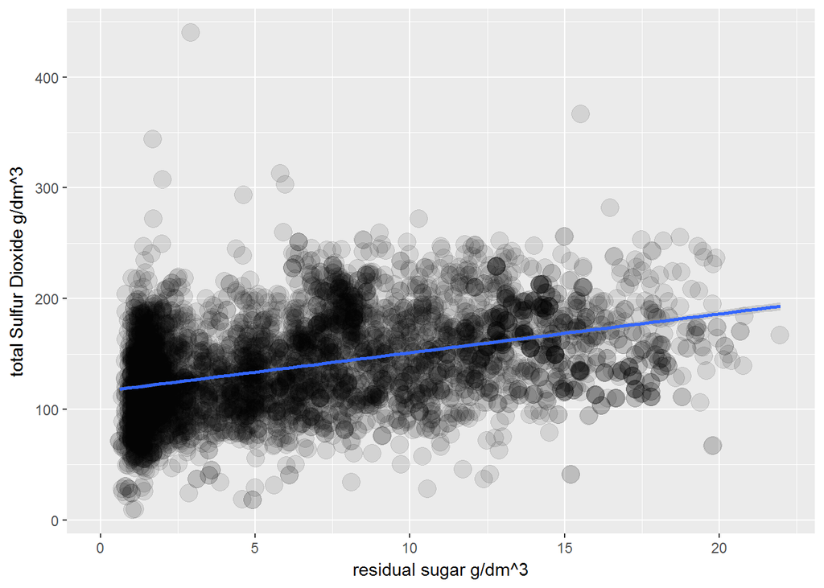

we can see a correlation between residual.sugar and total sulfur dioxide , from the line direction we can tell it’s positive correlation.

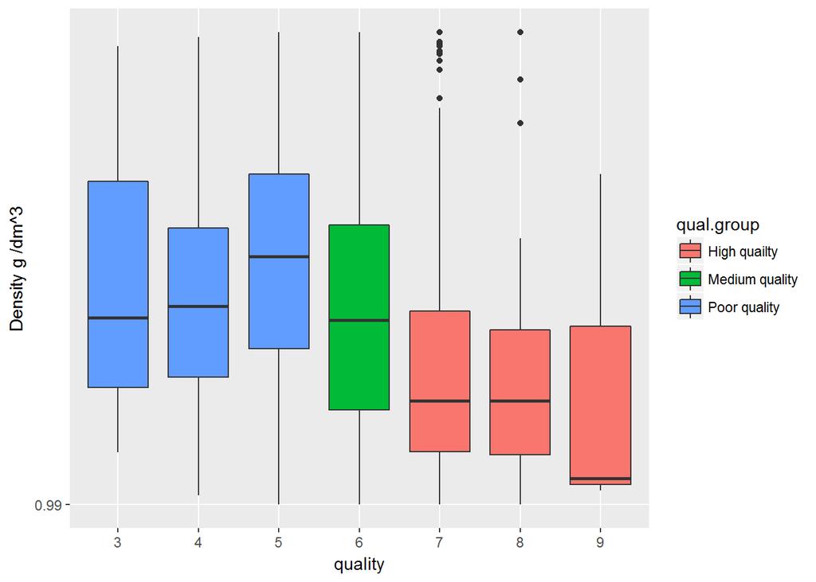

wines with higher quality have less density.

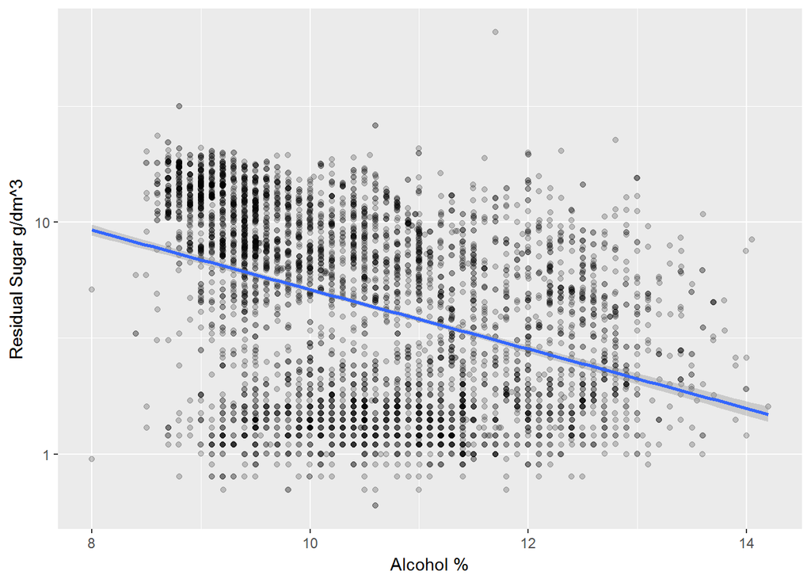

the more alcohol volume the less residual sugar, this is the main observation from this plot.

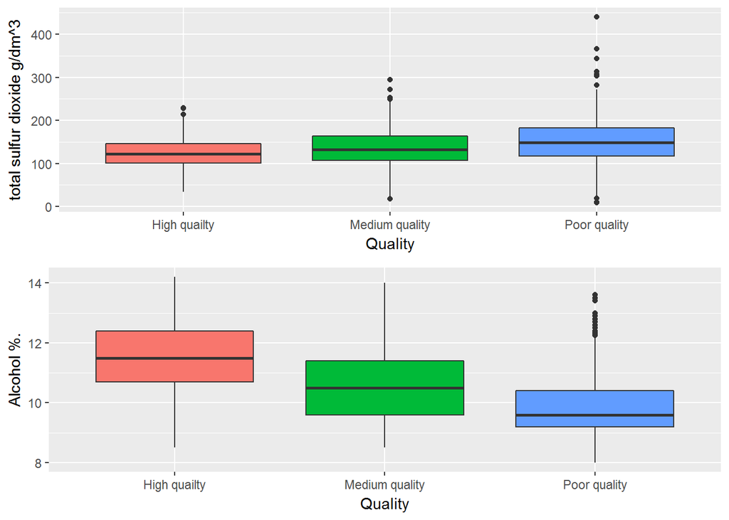

the alcohol shows shows that the high alcohol level is a factor to indicate a high quality wine, the total sulfur dioxide is the opposite with the poor quality group having higher sulfur dioxide rate.

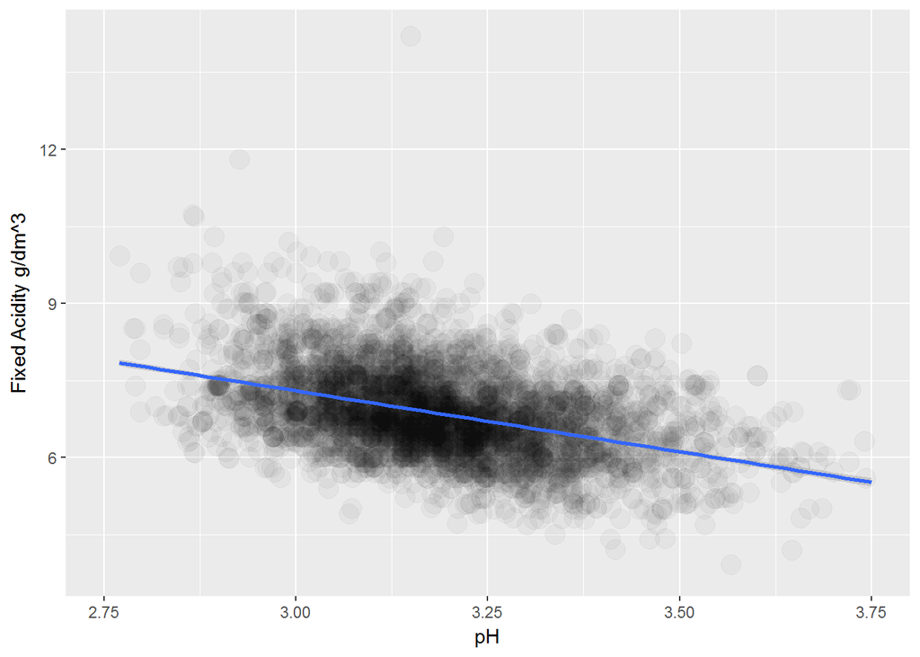

the fixed acidity seems to have a negative correlation with pH.

# Bivariate Analysis

### What was the strongest relationship you found?

# Multivariate Plots Section

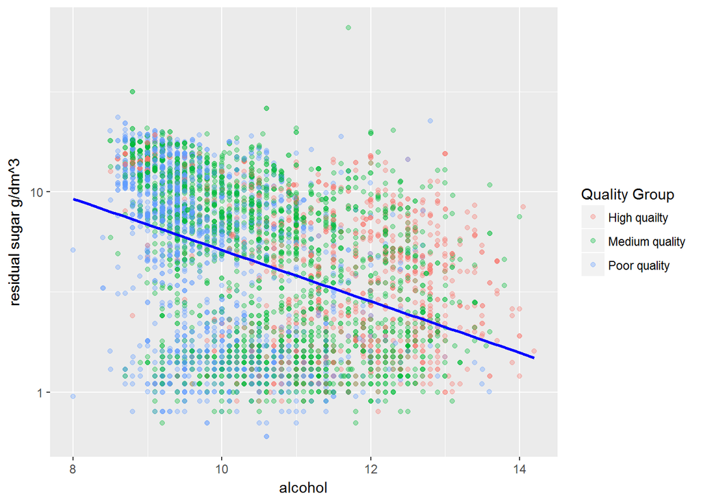

```
##
##  Pearson's product-moment correlation
##
## data:  wine$alcohol and wine$residual.sugar
## t = -35.321, df = 4896, p-value < 2.2e-16
## alternative hypothesis: true correlation is not equal to 0
## 95 percent confidence interval:
##  -0.4726723 -0.4280267
## sample estimates:
##        cor
## -0.4506312
```

looking to the test above and the plot as well, theres a significat negative correlation between residual sugar and alcohol volume.

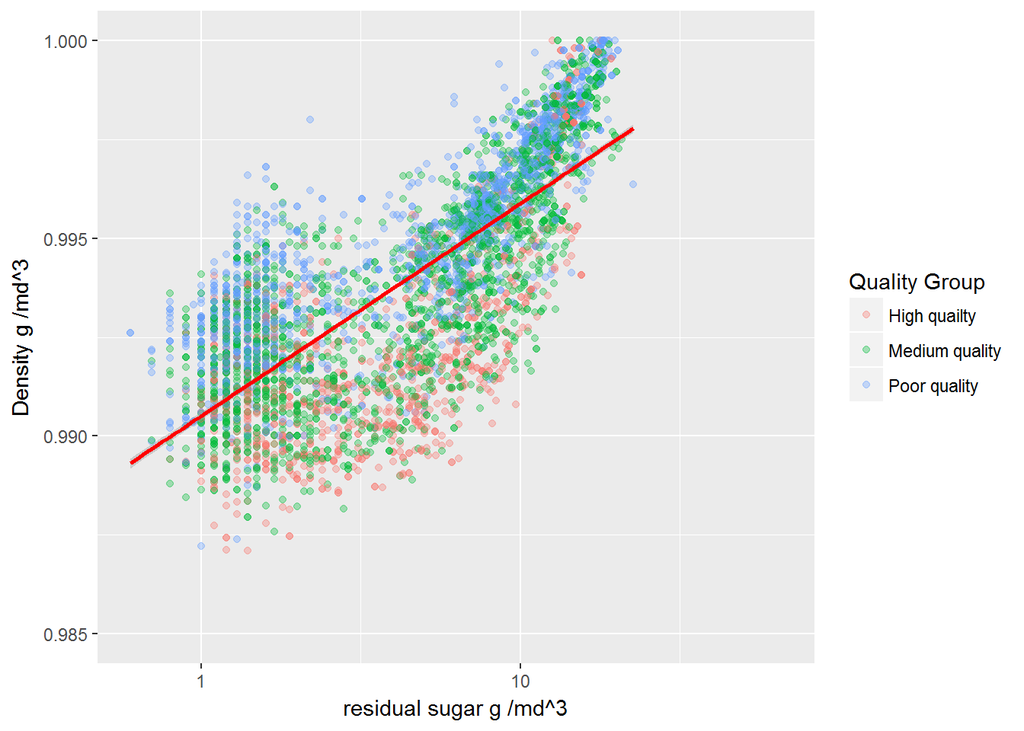

```
##
##  Pearson's product-moment correlation
##
## data:  wine$density and wine$residual.sugar
## t = 107.87, df = 4896, p-value < 2.2e-16
## alternative hypothesis: true correlation is not equal to 0
## 95 percent confidence interval:
##  0.8304732 0.8470698
## sample estimates:
##       cor
## 0.8389665
```

there’s a strong positive correlation and looking at the P-value we can tell that it’s signifacnt.

# Multivariate Analysis

### Talk about some of the relationships you observed in this part of the investigation. Were there features that strengthened each other in terms of looking at your feature(s) of interest?

the sugar and density, with correaltion score of .83

### Were there any interesting or surprising interactions between features?

the residual sugar and high quality group values are scattered, which makes is difficalt to tell if there’s a relationship !

### OPTIONAL: Did you create any models with your dataset? Discuss the strengths and limitations of your model.

# Final Plots and Summary

### Plot One

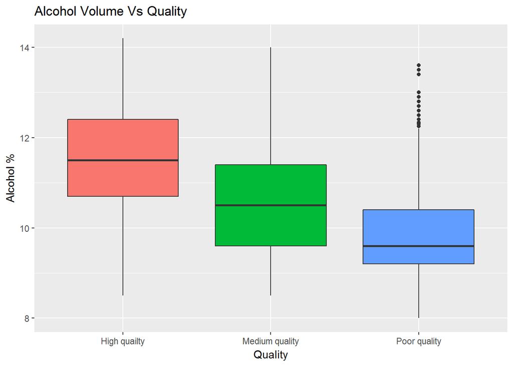

```
## # A tibble: 3 × 4
##       qual.group mean.alcohol median.alcohol number
##            <chr>        <dbl>          <dbl>  <int>
## 1   High quailty     11.41602           11.5   1060
## 2 Medium quality     10.57537           10.5   2198
## 3   Poor quality      9.84953            9.6   1640
```

### Plot Two

[output not shown]

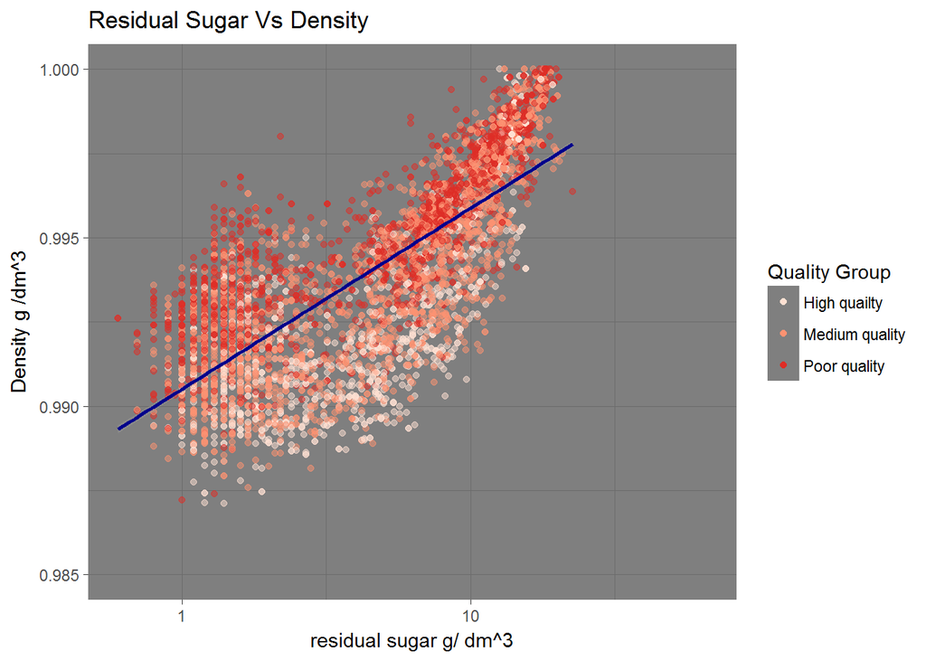

### Description Two

due to the high correaltion beatween the residual sugar and wine density level. the wine with low density have higher quality score (based on a previous plot), therefore the residual sugar and density are factors of high qualty wines.

### Plot Three

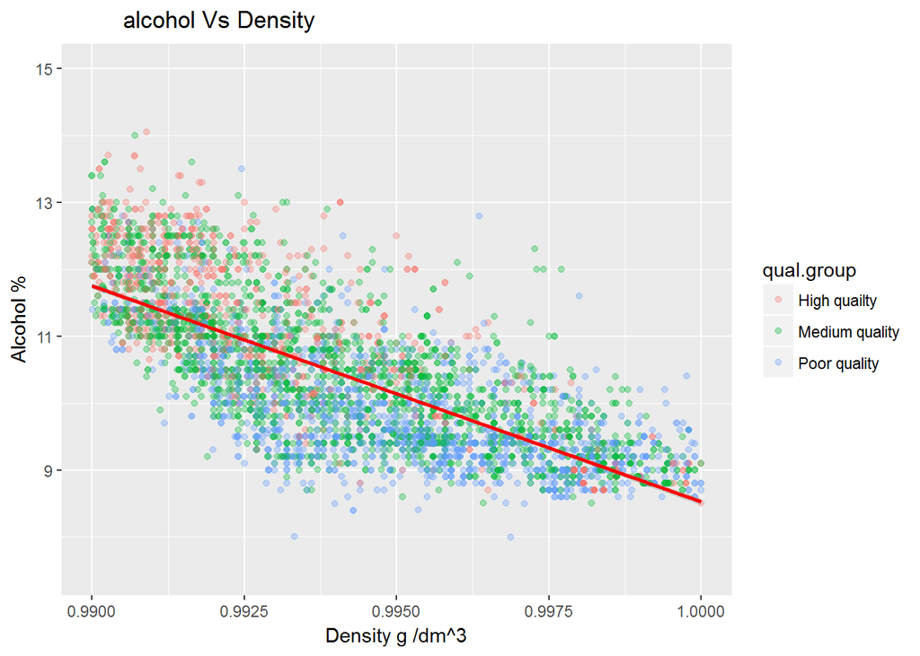

### Description Three

after we came into conclusion that the low density and high alcohol level are the strongest factors in wine quality, this plot approves the conclusion, with high quality wines positioned in the top left corner(low density and high alcohol volume)

### Reflection:

the main purpose of this EDA was to find the main factors that lead the experts to give higher vote for wines, and i found out that the density and alcohol are the main variables for high quality wines,on the other hand i couldn’t tell the realtion between residual sugar and wine quality untill i calculated the correlation between density and residual sugar; knowing that correlation deasn’t imply cauastion, the correlation was high and helped me to make an illustarion about the relation residual sugar and wine quality.

almost 80% of the data is at 6 qualty rating or below, having more varibles of the high quality will lead to a better judgement in the future.